# PS 15 Section 4

##REMINDERS 1. KNIT AS YOU GO! 2. ALWAYS SET YOUR WORKING DIRECTORY FIRST 3. MAKE SURE YOU KNOW WHAT YOUR VARIABLES ARE (X and Y, ORDER MATTERS) 4. KEEP CHUNKS TOGETHER EVEN IF THE PROBLEM SET SAYS DIFFERENTLY 5. PUT TEXTBOOK ANSWERS UNDER THE QUESTION 6. YOU CAN WORK TOGETHER, BUT PLEASE WRITE ANSWERS IN YOUR OWN WORDS (object names too)

STEP 1. GET AND SET WORKING DIRECTORY

```r
getwd()
```

```
## [1] "/home/jovyan/UCSB_POLS15/Section 4"
```

```r
setwd("/home/jovyan/UCSB_POLS15/Section 4")
```

STEP 2. LOAD LUNG CAPACITY DATASET

```r
lungdata <- read.csv("lungcapdata.csv", header = T)

class(lungdata$Age)
```

```
## [1] "integer"
```

```r
# What type of variable is age?
```

STEP 3. PRODUCE A SCATTERPLOT WITH AGE ON HORIZONTAL AXIS, AND LUNG CAPACITY ON THE VERTICAL AXIS. IV? DV?

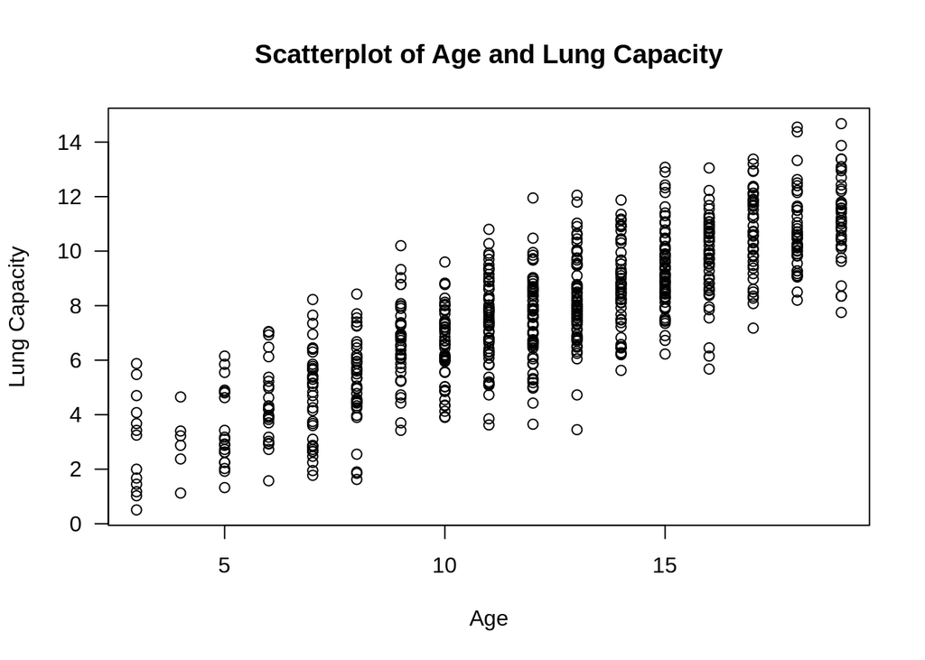

```r
plot(lungdata$Age, lungdata$LungCap, main = "Scatterplot of Age and Lung Capacity",
     xlab = "Age", ylab = "Lung Capacity",
     las = 1) #las = 1 makes the labels on Y axis horizontal
```

STEP 4. ADD A REGRESSION LINE TO THE PLOT

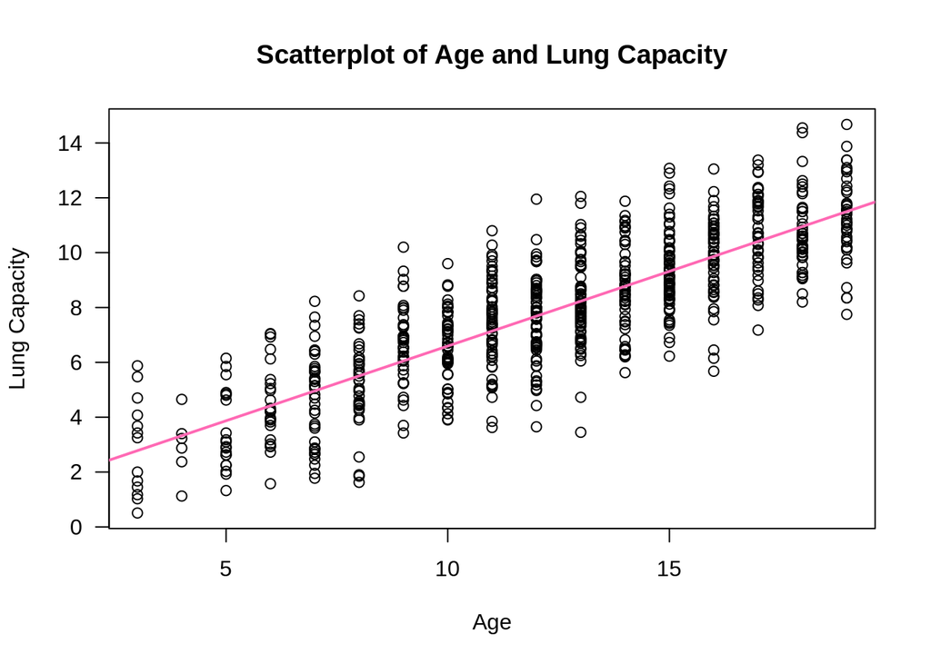

```r
plot(lungdata$Age, lungdata$LungCap,
     main = "Scatterplot of Age and Lung Capacity",
     xlab = "Age", ylab = "Lung Capacity", las = 1)

model1 <- lm(lungdata$LungCap ~ lungdata$Age, data=lungdata)

abline(model1, col = "hot pink", lwd = 2)
```

STEP 5. ESTIMATE AND REPORT THE CORRELATION AND THE COVARIANCE OF “AGE” WITH “LUNGCAP”

```r
cor(lungdata$Age, lungdata$LungCap)
```

```
## [1] 0.8196749
```

```r
cov(lungdata$Age, lungdata$LungCap)
```

```
## [1] 8.738289
```

```r
# What is the difference between correlation and covariance?
```

STEP 6. WRITE DOWN THE MODEL WE ARE FITTING WHEN WE DO A LINEAR REGRESSION OF “LUNGCAP” ON “AGE” USING BETA0, AND BETA1 WHERE NECESSARY.

$LungCap_i = \beta_0 + \beta_1Age_i + \epsilon_i$

Make sure you understand what $\beta_0$ and $\beta_1$ mean!

STEP 7. INTERPRET THE RESULTS OF THE LINEAR REGRESSION

```r
model1 <- lm(lungdata$LungCap ~ lungdata$Age, data = lungdata)
summary(model1)
```

```
##
## Call:
## lm(formula = lungdata$LungCap ~ lungdata$Age, data = lungdata)
##
## Residuals:
##     Min      1Q  Median      3Q     Max
## -4.7799 -1.0203 -0.0005  0.9789  4.2650
##
## Coefficients:
##              Estimate Std. Error t value Pr(>|t|)
## (Intercept)   1.14686    0.18353   6.249 7.06e-10 ***
## lungdata$Age  0.54485    0.01416  38.476  < 2e-16 ***
## ---
## Signif. codes:  0 '***' 0.001 '**' 0.01 '*' 0.05 '.' 0.1 ' ' 1
##
## Residual standard error: 1.526 on 723 degrees of freedom
## Multiple R-squared:  0.6719, Adjusted R-squared:  0.6714
## F-statistic:  1480 on 1 and 723 DF,  p-value: < 2.2e-16
```

STEP 8. INTERPRET THE MEANING OF THE COEFFICIENT ESTIMATES (BOTH INTERCEPT AND COEFFICIENTS ON “AGE”)

1. Usually, we don’t interprete the intercept.
2. The coefficient on the IV (B1) means the one-year change in age is associated with 0.545 higher expected (or say, predicted) lung capacity.

STEP 9. EXPLORE THE RELATIONSHIP BETWEEN GENDER AND LUNG CAPACITY (MODEL, SCATTERPLOT & INTERPRET COEFFICIENT)

```r
#Please type your code here!
```